# RMedlineFunctions Examples ‘rituximab and vaccines’

This is a first attempt at building an example of RMedlineFunctions (https://github.com/fdsayre/RMedlineFunctions) using an RNoteBook to display some results.

This example uses ‘rituximab AND (vaccine OR vaccination)’ as a search query.

Load functions and libraries

```r
library(rworldmap)
```

Set query (can be anything you would search in pubmed.gov) retrieve medline data file

The turn that medline data file into a data frame with most article metadata (but not all!)

```r
data <- RetrieveArticleData(query,2000,2019,5000)
```

```
longer object length is not a multiple of shorter object lengthlonger object length is not a multiple of shorter object length
```

Let’s take a quick look at how pubmed translated that query

```r
Query(data)
```

```
[1] "(\"rituximab\"[MeSH Terms] OR \"rituximab\"[All Fields]) AND ((\"vaccines\"[MeSH Terms] OR \"vaccines\"[All Fields] OR \"vaccine\"[All Fields]) OR (\"vaccination\"[MeSH Terms] OR \"vaccination\"[All Fields])) AND 2000[EDAT] : 2019[EDAT]"
```

Create a basic bar chart shorting publication frequency by year from article metadata file (must contain at least a Year variable)

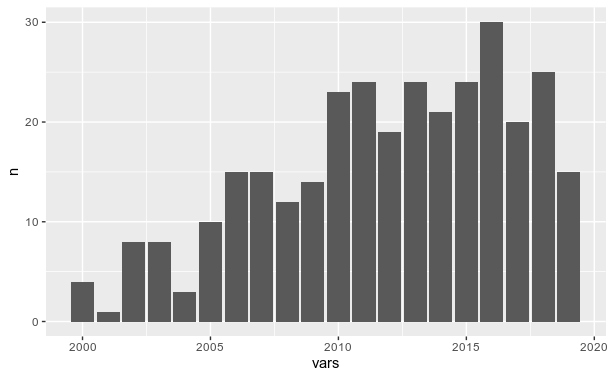

Plot article status using medline data file

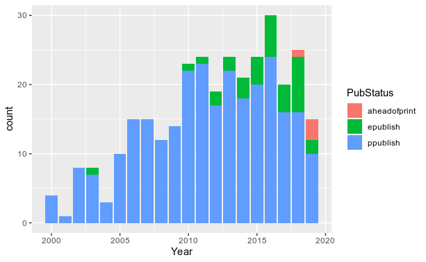

Get data on number of times each article has been cited and add that data to an existing article metadata file.

WARNING: CITATION DATA TAKES A LONG TIME TO COLLECT

variables for function: x = medline data file y = article metadata file that has PMIDs

```r
article_metadata_citations <- GetCitationData(data, article_metadata)
```

Plot citations for each paper as a scatterplot (each dot is independent)

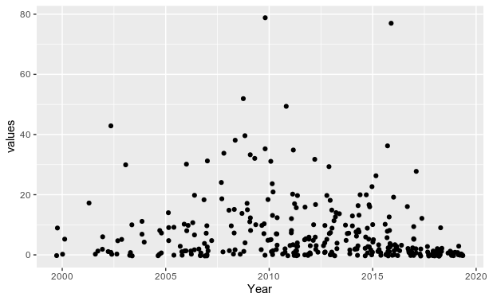

Bar graph of culumative citations by year This is really the total number of citations, so not incredibly useful

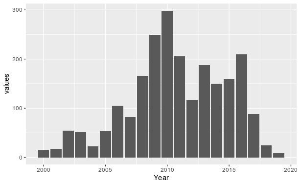

Testing MapPubsPerCountry function, which counts the frequency of articles published in particular countries

```
25 codes from your data successfully matched countries in the map
0 codes from your data failed to match with a country code in the map
     failedCodes failedCountries
219 codes from the map weren't represented in your data
```

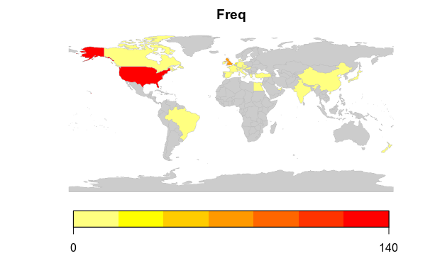

```r
MapPubsPerCountry(data,article_metadata_citations)
```